# Limited Efforts with Non-binary Identification

Hongyi Xu - Stockholm School of Economics

2022-09-19

> [J&J Spin-offs](https://www.reuters.com/business/healthcare-pharmaceuticals/johnson-johnson-plans-split-into-two-companies-wsj-2021-11-12/)

#### Preface

In the parsimonious model in the [previous document](https://hongyileoxu.github.io/research/TCP_Project/TCP_Project_Model2.html), we assume that investors identify the entrepreneur as either a Good or Bad type, based on their homogeneous belief about whether the probability of being a Good type surpasses a predetermined level. Mathematically, this identification procedure simplify our model; however, this assumption is not only unrealistic, but also making investors’ belief updating process redundant. In this document, we will relax investors’ binary identification assumption, adding the impact of investors’ belief into financial constraints, to build a more rigorous model.

#### 2.1 General Assumptions

> Similar to all notations in [document](https://hongyileoxu.github.io/research/TCP_Project/TCP_Project_Model2.html), we just copy paste most of those parts here. However, the identification process is different from that in the previous doc.

Denote the two independent and identical projects as $a$ and $b$ and the entity combining two projects is called “the company”. The effort level of the entrepreneur is denoted as $E$. We set $E \in \{0,1\}$ when the entrepreneur runs only one project and $E=1$ means that the entrepreneur exerts high effort, while $E=0$ means the entrepreneur shirks. And $E \in \{0, 1, 2\}$ when the entrepreneur manages the company with each value corresponding to shirk on both projects, exert efforts on only one projects and exert efforts on both projects. The asset contributed by the entrepreneur to each project is $A \geq \bar{A} = I - p_H(R - \frac{B}{\Delta p})$ and the total investment for each project if $I$. *At the beginning of each period, the entrepreneur will be given wealth* $2A$, which can be used for project investments or consumption. And at the end of each period, the entrepreneur will consume all payoffs and leave nothing to the next period. In addition, for each project, the probability of success and generating cash flow $R$ is $p_H$ when the entrepreneur exerts effort on that project and $p_L$ if the entrepreneur shirks. And $p_H R \geq I \geq p_L R$. The private benefit for the entrepreneur in this case equals to $B(2-E)$ when $E \in \{0,1,2\}$.

The entrepreneur can be either a Good type or a Bad type. The difference is that the Good type does not have an upper bound for the effort level $E$, while the Bad type has an upper bound $\bar{E}$ such that $E \leq \bar{E}$. For simplicity, we set $\bar{E}=1$ meaning that the Bad type entrepreneur can only exert efforts on maximum one project. But for the Good type, she can choose to exert efforts on both projects. Meanwhile, we assume that a signal $X_0$, which is the only information regarding the company operation, will be received just before the end of each period. And we define $X_0$ as the success and failure outcome of each project. Investors, with a prior probability of the entrepreneur being a Good type, can update their beliefs conditional on the signal $X_0$ they received. And different from previous settings, now investors will incorporate their prior and posterior probabilities into their financing decisions, rather than just using it for identifying the entrepreneur type.

Align with notations in section 1.4 in the [document](https://hongyileoxu.github.io/research/TCP_Project/TCP_Project_Model2.html), we set investors’ prior belief towards the entrepreneur type $T$, at $t=0$, as
$$\mathbb{P}(T) = \begin{cases}
q_0 \quad &\text{, if } T = G \\
1-q_0 \quad &\text{, if } T = B,
\end{cases}$$
where $q_0 > 0$ and variable $T \in \{G, B\}$ denotes the type of the entrepreneur, with $G$ and $B$ representing the Good and Bad type respectively. *And this investors’ prior and all following posterior beliefs are public information available to the entrepreneur.*

The whole projects live for two periods - period 1 and period 2 - and three dates ($t = 0, 1, 2$). At the beginning of each period, the entrepreneur needs to seek financing for the company/projects. At $t=0$, she needs to decide whether she wants to diversify by adding and operating project $b$ in additional to project $a$. And at $t=1$, she needs to decide whether to keep company’s current structure, or conduct a corporate spin-off, breaking the company into two new entities based upon project $a$ and $b$. Finally, we assume that the entrepreneur has *the bargaining power* and will propose contracts to *competitive* investors.

#### 2.2 Optimal Contract after Diversification

The decision of diversification still depends on two factors. First, whether the joint firm can receive external financing from investors. Second1, whether the manager can achieve a higher utility through this diversification. However, now investors will incorporate their priors into their financing decision, which will directly impact the first factor and indirectly affect the second.

We start by formulating entrepreneur’s optimization question and find the optimal contract for the Good and Bad entrepreneur, and then deriving the necessary condition for the manager to diversify.

The optimization problem for a Good entrepreneur can be set up like this
$$\begin{align}
& \quad \max_{R_b(r)} \sum_{r \in \Omega} R_b(r) \mathbf{P}(r |
E = 2) \quad \text{ s.t. }\\
(\text{PC}) & \quad \sum_{r \in \Omega} (r - R_b(r)) \Big[ q_0
\mathbf{P}(r | E = 2) + (1-q_0) \mathbf{P}(r | E = 1) \Big] \geq 2 (I -
A) \tag{1} \\
(\text{IC}_1) & \quad \sum_{r \in \Omega} R_b(r) \mathbf{P}(r |
E = 2) \geq \sum_{r \in \Omega} R_b(r) \mathbf{P}(r | E = 1) + B \tag{2}
\\
(\text{IC}_2) & \quad \sum_{r \in \Omega} R_b(r) \mathbf{P}(r |
E = 2) \geq \sum_{r \in \Omega} R_b(r) \mathbf{P}(r | E = 0) + 2B
\tag{3} \\
(\text{IC}_3) & \quad \sum_{r \in \Omega} R_b(r) \mathbf{P}(r |
E = 1) \geq \sum_{r \in \Omega} R_b(r) \mathbf{P}(r | E = 0) + B \tag{4}
\end{align}$$

In this version of optimization problem, we incorporate investors prior beliefs into the (PC) constraint and add a new (IC<sub>3</sub>) constraint to incentivize a Bad entrepreneur to choose $E=1$. (IC<sub>1</sub>) and (IC<sub>2</sub>) are used to incentivize the entrepreneur to choose $E=2$ if she is a Good type, while the new (IC<sub>3</sub>) is applied when she is a Bad type, incentivizing her to choose $E=1$. This setting is consistent both the (PC) constraint and the fact that both projects are negative NPV projects when the entrepreneur does not exert effort. And we can write the Lagrangian

$$\begin{equation}
\begin{split}
\mathcal{L} = & \sum_{r \in \Omega} R_b(r) \mathbf{P}(r | E = 2)
\\
& + \lambda_{PC} \bigg \{ \sum_{r \in \Omega} \Big[ r - R_b(r)
\Big] \Big[ q_0 \mathbf{P}(r | E = 2) + (1-q_0) \mathbf{P}(r | E = 1)
\Big] - 2 (I - A) \bigg \} \\
& + \lambda_{IC1} \Big \{ \sum_{r \in \Omega} R_b(r) \big
[\mathbf{P}(r | E = 2) - \mathbf{P}(r | E = 1) \big ] - B \Big \} \\
& + \lambda_{IC2} \Big \{ \sum_{r \in \Omega} R_b(r) \big
[\mathbf{P}(r | E = 2) - \mathbf{P}(r | E = 0) \big ] - 2B \Big \} \\
& + \lambda_{IC3} \Big \{ \sum_{r \in \Omega} R_b(r) \big
[\mathbf{P}(r | E = 1) - \mathbf{P}(r | E = 0) \big ] - B \Big \}
\end{split}
\end{equation}\tag{5}$$

FOC:

$$\begin{align}
\frac{\partial \mathcal{L}}{\partial R_b(r)} & = \mathbf{P}(r|E=2)
- \lambda_{PC} \big \{ q_0 \mathbf{P}(r | E = 2) + (1-q_0) \mathbf{P}(r
| E = 1) \big \} \\
& + \lambda_{IC1} \big \{ \mathbf{P}(r|E=2) - \mathbf{P}(r|E=1)
\big \} + \lambda_{IC2} \big \{ \mathbf{P}(r|E=2) - \mathbf{P}(r|E=0)
\big \} \\
& + \lambda_{IC3} \big \{ \mathbf{P}(r|E=1) - \mathbf{P}(r|E=0)
\big \} = 0, \quad \forall r \in \{2R, R, 0\}
\end{align} \tag{6}$$
For $r = 2R$, we know that $\mathbf{P}(r|E=2) > \mathbf{P}(r|E=1) > \mathbf{P}(r|E=0)$. And $\frac{\partial \mathcal{L}}{\partial R_b(r)} \bigr|_{r=2R} = 0$ implies that (PC) binds and $\lambda_{PC} > 1$. For $r = R$, we can see that

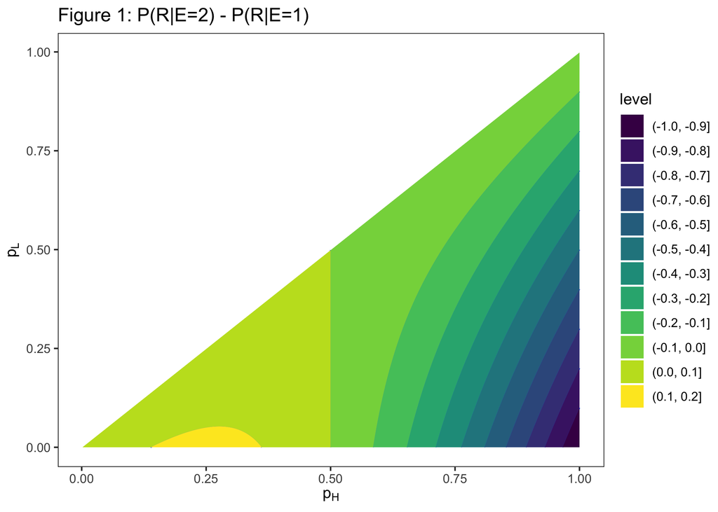

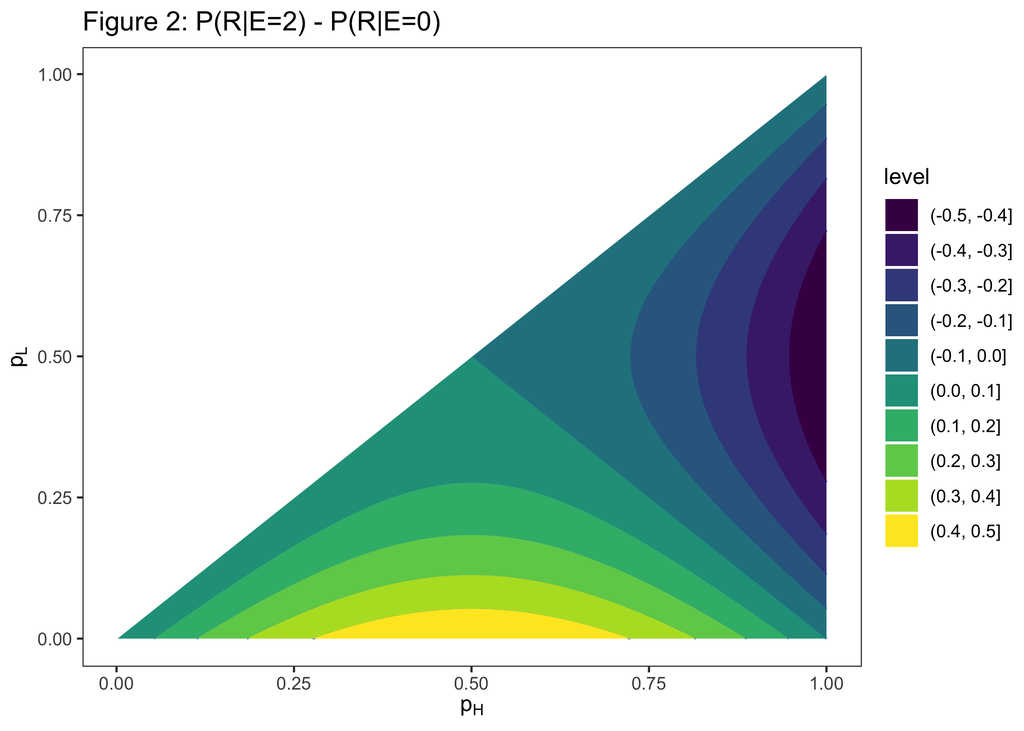

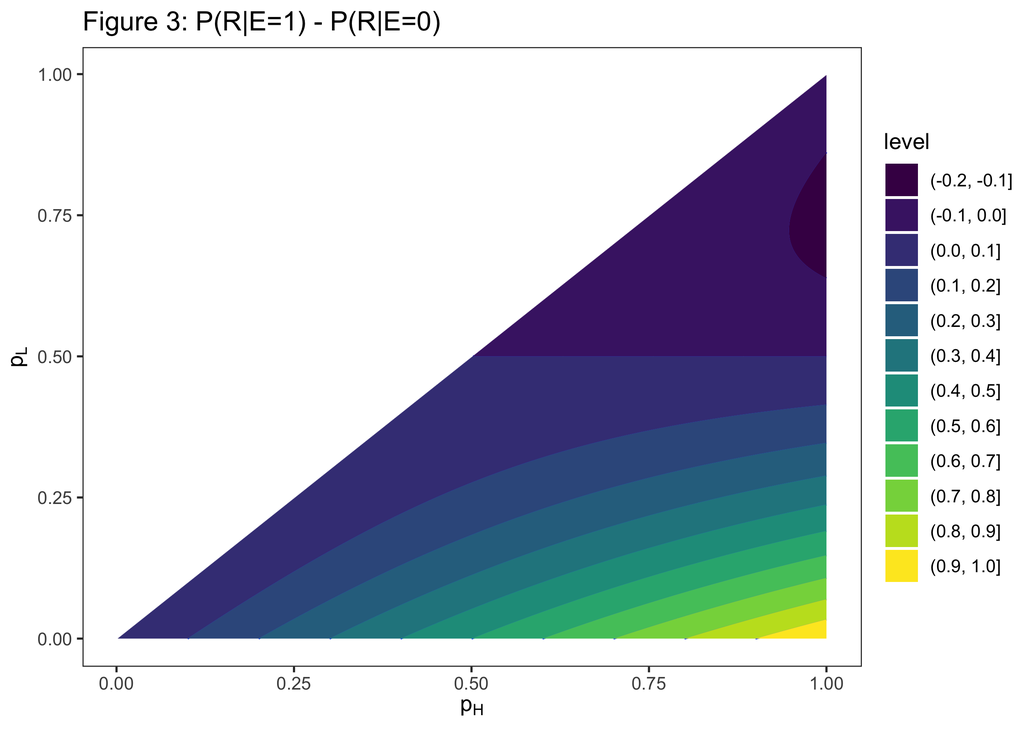

Above three graphs show the impact of different projects towards differences in conditional probabilities on effort level. However, just for the purpose of this model, we know that the optimal contract by a Good entrepreneur must lie on the (PC) constraint. And assuming the existence of optimal contract(s), we can rewrite Eq (1) as

$$\begin{align}
(\text{PC}) \quad & \sum_{r \in \Omega} (r - R_b(r)) \Big[ q_0
\mathbf{P}(r | E = 2) + (1-q_0) \mathbf{P}(r | E = 1) \Big] = 2 (I -
A) \\
\implies & \sum_{r \in \Omega} r \Big[ q_0 \mathbf{P}(r | E = 2) +
(1-q_0) \mathbf{P}(r | E = 1) \Big] \\
- & \sum_{r \in \Omega} R_b(r) \Big[ q_0 \mathbf{P}(r | E = 2) +
(1-q_0) \mathbf{P}(r | E = 1) \Big] = 2(I-A) \\
\implies & 2 p_H R q_0 + (p_H + p_L) R (1-q_0) - F_2 q_0 - F_1
(1-q_0) = 2(I-A),
\end{align} \tag{7}$$
where the first and second terms relates to the conditional expected cash flow from the joint firm and the $F_2$ and $F_1$ relates to the conditional (expected) agency rent to the entrepreneur. Particularly, $F_2 = \sum_{r \in \Omega} R_b(r) \mathbf{P}(r | E = 2)$ and $F_1 = \sum_{r \in \Omega} R_b(r) \mathbf{P}(r | E = 1)$.

For a Bad entrepreneur, assuming $E=1$ being her optimal action, the optimization problem is
$$\begin{align}
& \quad \max_{R_b(r)} \sum_{r \in \Omega} R_b(r)
\color{red}{\mathbf{P}(r | E = 1)} + \color{red}{B} \quad \text{ s.t.
}\\
(\text{PC}) & \quad \sum_{r \in \Omega} (r - R_b(r)) \Big[ q_0
\mathbf{P}(r | E = 2) + (1-q_0) \mathbf{P}(r | E = 1) \Big] \geq 2 (I -
A) \\
(\text{IC}_1) & \quad \sum_{r \in \Omega} R_b(r) \mathbf{P}(r |
E = 2) \geq \sum_{r \in \Omega} R_b(r) \mathbf{P}(r | E = 1) + B \\
(\text{IC}_2) & \quad \sum_{r \in \Omega} R_b(r) \mathbf{P}(r |
E = 2) \geq \sum_{r \in \Omega} R_b(r) \mathbf{P}(r | E = 0) + 2B \\
(\text{IC}_3) & \quad \sum_{r \in \Omega} R_b(r) \mathbf{P}(r |
E = 1) \geq \sum_{r \in \Omega} R_b(r) \mathbf{P}(r | E = 0) + B
\end{align} \tag{8}$$
Follow the same logic, we can see that (PC) must bind for the existence of at least one optimal contract. Combining with our analysis for a Good and Bad entrepreneur, we know the optimal contract for these two types are different, unless only one optimal contract exists for both types. So, the Bad type entrepreneur has will want to mimic the action of a Good, since, otherwise, the Bad type will signal her type to the market. So, we know that the Bad entrepreneur will propose the same contract as a Good type and we can analyse the conditions for a Bad type to proceed with a diversification in the next section.

#### 2.3 Whether to Diversify, Again!

Since we know the proposed contract will be unique regardless of the entrepreneur type, we can go backwards to see that given this contract, what are the necessary conditions for the (Good and Bad) entrepreneur(s) to proceed with a diversification.

Since, both the Good and Bad entrepreneurs propose the same contract to the market, this relationship must hold that
$$F_2 q_0 + F_1 (1-q_0) = 2 p_H R q_0 + (p_H + p_L) R (1-q_0) - 2(I-A).
\tag{9}$$
So, the necessary condition for the Good entrepreneur to diversify is
$$F_2 = \max_{R_b(r)} \sum_{r \in \Omega} R_b(r) \mathbf{P}(r | E = 2)
\geq p_H R - I + 2A.$$
And we bring this back into Eq (9) and get
$$\begin{gathered}
2 p_H R q_0 + (p_H + p_L) R (1-q_0) - 2(I-A) = (p_H R - I + 2A) + (p_L
R - I) + \Delta p R q_0 \\
\geq (p_H R - I + 2A)q_0 + F_1 (1-q_0) \\
\implies F_1 \leq (p_H R - I + 2A) + \frac{(p_L R - I) + \Delta p R
q_0}{1-q_0}.
\end{gathered} \tag{10}$$

Now let’s analyse the condition for a Bad entrepreneur to diversify, which is
$$F_1 + B = \max_{R_b(r)} \sum_{r \in \Omega} R_b(r) \mathbf{P}(r | E = 1)
+ B \geq p_H R - I + 2A \implies F_1 \geq (p_H R - I + 2A) - B.$$
Combining with Eq (10), we know that *both the Good and Bad entrepreneur choose diversification* if and only if
$$\frac{(p_L R - I) + \Delta p R q_0}{1-q_0} \geq -B.$$
Otherwise, one of two types of entrepreneur will not choose to diversify. In other words, investors know only a certain type of entrepreneur will proceed diversification and this information asymmetry will no longer have an impact in the contracting, **assuming that all types of entrepreneurs are only different in their maximum effort levels (i.e. abilities)**.

So, the our situation of interest is that both the Good and Bad type entrepreneur choose to diversify and will propose the same contract. Assuming the joint firm will be financed by the market, this creates information asymmetry between the entrepreneur and investors. In the next section, we analyse how investors update their beliefs towards the type of entrepreneur and how the entrepreneur’s corporate spin-off decision relates to investors’ learning.

#### 2.4 How Do Investors Update Beliefs?

In this section, we analyse how the investors’ belief on the type of the entrepreneur changes at the beginning of period 2, given the signal $X_0$ just before $t=1$. The signal $X_0$ here assumes to be the only accessible information of the project towards investors and we simplify it here to be the outcome of two projects, i.e. $X_0 \in \{2R, R, 0\}$. We define the variable $T \in \{G, B\}$ as the type of the entrepreneur, where $G$ denotes the Good type and $B$ denotes the Bad type. And investors’ belief at the beginning of period 1 is
$$\mathbb{P}(T) = \begin{cases}
q_0 \quad &\text{, if } T = G \\
1-q_0 \quad &\text{, if } T = B,
\end{cases}$$
And based on our previous assumption that the signal is equivalent to the project outcome in period 1, we have that
$$\mathbb{P}(X_0 | T = G) = \begin{cases}
p_H^2 &\text{, if } X_0 = 2R \\
2 p_H (1-pH) &\text{, if } X_0 = R \\
(1 - p_H)^2 &\text{, if } X_0 = 0.
\end{cases}$$
Therefore, investors can use the Bayes rule to update their beliefs towards the type of the entrepreneur at $t=1$, before deciding whether to continue to finance the company. We can get
$$\mathbb{P}(T = G | X_0) = \frac{\mathbb{P}(X_0 | T = G) \mathbb{P}(T =
G)}{\mathbb{P}(X_0)}
= \frac{\mathbb{P}(X_0 | T = G) q_0}{\mathbb{P}(X_0 | T = G) q_0 +
\mathbb{P}(X_0 | T = B) (1-q_0)}.$$
Specifically, we have
$$\mathbb{P}(T = G | X_0 = 2R) = \frac{p_H^2 q_0}{p_H^2 q + p_H p_L (1-q)}
= \frac{1}{1 + \frac{p_L}{p_H} \frac{1-q}{q}} > \frac{1}{2},$$
$$\mathbb{P}(T = G | X_0 = R) = \frac{2 p_H (1-p_H) q}{2 p_H (1-p_H) q +
[p_H (1-p_L) + (1-p_H) p_L] (1-q)}$$
$$= \frac{1}{1 + \frac{p_H (1-p_L) + (1-p_H) p_L}{2 p_H (1-p_H)}
\frac{1-q}{q}},$$
$$\text{&} \quad \mathbb{P}(T = G | X_0 = 0) = \frac{(1-p_H)^2
q}{(1-p_H)^2 q + (1-p_H) (1-p_L) (1-q)} = \frac{1}{1 +
\frac{1-p_L}{1-p_H} \frac{1-q}{q}} > \frac{1}{2}.$$

In summary, we have that
$$q_1 = \mathbb{P}(T = G | X_0) =
\begin{cases}
\frac{1}{1 + \frac{p_L}{p_H} \frac{1-q}{q}} \quad & \text{, if }
X_0 = 2R \\
\frac{1}{1 + \frac{p_H (1-p_L) + (1-p_H) p_L}{2 p_H (1-p_H)}
\frac{1-q}{q}} \quad & \text{, if } X_0 = 2 \\
\frac{1}{1 + \frac{1-p_L}{1-p_H} \frac{1-q}{q}} \quad & \text{, if
} X_0 = 0. \\
\end{cases}$$
Then, with this updated belief of the entrepreneur being a Good type, $q_1$, the (PC) constraint will be modified with the three incentive constraints remained. Since the Bad entrepreneur will continue to mimic the contract proposed by the Good type, if $q_1 < q_0$, there will be two cases (1) no optimal contract exists (2) the joint firm can still be financed. We explain the entrepreneur’s incentives to adopt a corporate spin-off in these two cases.

## A New Output Format

`html_pretty` in the [**prettydoc**](https://github.com/yixuan/prettydoc/) package is a new output format for creating HTML documents from R Markdown files. `html_pretty` is more lightweight compared to `html_document`, and is more stylish than `html_vignette` when creating package vignettes.

## New Styles

`html_pretty` currently supports three page themes (`cayman`, `tactile` and `architect`), and two syntax highlight styles (`github` and `vignette`). The theme and highlight styles can be specified in the document metadata, for example:

```yaml
output:
  prettydoc::html_pretty:
    theme: architect
    highlight: github
```

## Your Familiar Tools

Feel free to use the `knitr` infrastructure with dozens of tunable options in your document.

```r
set.seed(123)
n <- 1000
x1  <- matrix(rnorm(n), ncol = 2)
x2  <- matrix(rnorm(n, mean = 3, sd = 1.5), ncol = 2)
x   <- rbind(x1, x2)
head(x)
```

```
##             [,1]        [,2]
## [1,] -0.56047565 -0.60189285
## [2,] -0.23017749 -0.99369859
## [3,]  1.55870831  1.02678506
## [4,]  0.07050839  0.75106130
## [5,]  0.12928774 -1.50916654
## [6,]  1.71506499 -0.09514745
```

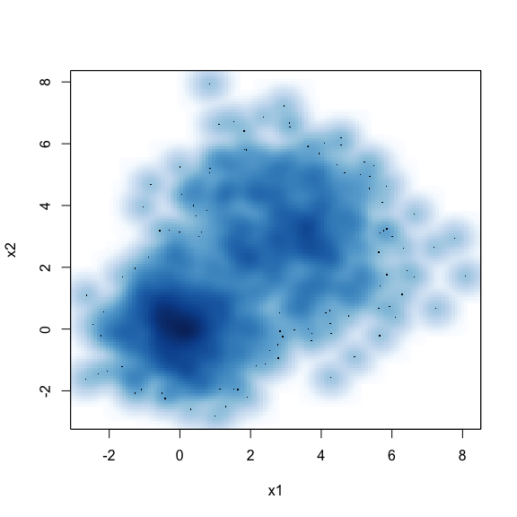

```r
smoothScatter(x, xlab = "x1", ylab = "x2")
```

You can include code snippets of languages other than R, but note that the block header has no curly brackets around the language name.

```cpp
// [[Rcpp::export]]
NumericVector timesTwo(NumericVector x) {
    return x * 2;
}
```

You can also write math expressions, e.g. $Y = X\beta + \epsilon$, footnotes[^1], and tables, e.g. using `knitr::kable()`.

| Sepal.Length | Sepal.Width | Petal.Length | Petal.Width | Species |
| --- | --- | --- | --- | --- |
| 5.1 | 3.5 | 1.4 | 0.2 | setosa |
| 4.9 | 3.0 | 1.4 | 0.2 | setosa |
| 4.7 | 3.2 | 1.3 | 0.2 | setosa |
| 4.6 | 3.1 | 1.5 | 0.2 | setosa |
| 5.0 | 3.6 | 1.4 | 0.2 | setosa |
| 5.4 | 3.9 | 1.7 | 0.4 | setosa |
| 4.6 | 3.4 | 1.4 | 0.3 | setosa |
| 5.0 | 3.4 | 1.5 | 0.2 | setosa |
| 4.4 | 2.9 | 1.4 | 0.2 | setosa |
| 4.9 | 3.1 | 1.5 | 0.1 | setosa |

## Stay Tuned

Please visit the [development page](https://github.com/yixuan/prettydoc/) of the `prettydoc` package for latest updates and news. Comments, bug reports and pull requests are always welcome.

[^1]: A footnote here.